# I Did Something About the Weather

24/05/2017

## About Me

**Currently:** A/Prof Field Crops Pathology @ USQ CCH, Toowoomba, AUS

**Previously:** Plant Disease Management Specialist @ IRRI, Los Baños, PHL

### R packages (on CRAN)

GSODR (Sparks, Hengl and Nelson)

getCRUCLdata (Sparks)

### R packages (not yet on CRAN)

bomrang (Sparks, Parsonage and Pembleton)

## GSOD Data

The GSOD or [Global Surface Summary of the Day (GSOD)](https://data.noaa.gov/dataset/global-surface-summary-of-the-day-gsod) station locations. US National Centers for Environmental Information, 1901-Present.

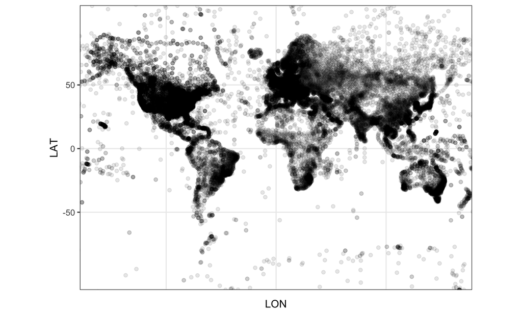

## GSOD Data Files

A raw data file

```
## # A tibble: 140 x 22
##   `STN---`  WBAN YEARMODA  TEMP    X5  DEWP    X7    SLP    X9   STP
##      <int> <int>    <int> <dbl> <int> <dbl> <int>  <dbl> <int> <dbl>
## 1   983280 99999 20170101  63.9     8  58.8     8 1011.0     8 852.8
## 2   983280 99999 20170102  66.4     7  57.5     7 1009.7     7 852.1
## 3   983280 99999 20170103  64.3     8  59.4     8 1010.0     8 852.1
## 4   983280 99999 20170104  66.5     8  59.8     8 1009.0     8 851.5
## # ... with 136 more rows, and 12 more variables: X11 <int>, VISIB <dbl>,
## #   X13 <int>, WDSP <dbl>, X15 <int>, MXSPD <dbl>, GUST <dbl>, MAX <chr>,
## #   MIN <chr>, PRCP <chr>, SNDP <dbl>, FRSHTT <chr>
```

## The Same Data File

Retrieved and parsed with GSODR

```
##      USAF  WBAN        STNID STN_NAME CTRY STATE CALL    LAT    LON ELEV_M
## 1: 983280 99999 983280-99999   BAGUIO   RP    NA RPUB 16.375 120.62 1295.7
## 2: 983280 99999 983280-99999   BAGUIO   RP    NA RPUB 16.375 120.62 1295.7
##    ELEV_M_SRTM_90m    BEGIN      END YEARMODA YEAR MONTH DAY YDAY TEMP
## 1:              NA 19490101 20170519 20170101 2017    01  01    1 17.7
## 2:              NA 19490101 20170519 20170102 2017    01  02    2 19.1
##    TEMP_CNT DEWP DEWP_CNT    SLP SLP_CNT   STP STP_CNT VISIB VISIB_CNT
## 1:        8 14.9        8 1011.0       8 852.8       8   9.5         8
## 2:        7 14.2        7 1009.7       7 852.1       7   9.7         7
##    WDSP WDSP_CNT MXSPD GUST  MAX MAX_FLAG  MIN MIN_FLAG PRCP PRCP_FLAG
## 1:  1.0        8     4   NA 22.6          14.6        *  0.8         G
## 2:  0.5        7     1   NA 24.8          15.0        *  0.0         I
##    SNDP I_FOG I_RAIN_DRIZZLE I_SNOW_ICE I_HAIL I_THUNDER I_TORNADO_FUNNEL
## 1:   NA     1              0          0      0         0                0
## 2:   NA     1              0          0      0         0                0
##     EA  ES   RH
## 1: 1.7 2.0 85.0
## 2: 1.6 2.2 72.7
```

## The GSODR Package

[figure not shown]

Adam H Sparks, Tomislav Hengl and Andrew Nelson (2017). GSODR: Global Summary Daily Weather Data in R. The Journal of Open Source Software, 2(10). DOI: 10.21105/joss.00177. URL: https://doi.org/10.21105%2Fjoss.00177

## Functions in GSODR

- `get_GSOD()` - queries and transfers files from the FTP server, reformats them and returns a `tibble()` object in R session or saves a file to disk with options for a GeoPackage spatially enabled file or comma separated values (CSV) file,
- `reformat_GSOD()` - the workhorse, takes individual station files on the local disk and reformats them, returns a `tibble()` object in R session or saves a file to disk with options for a GeoPackage spatially enabled file or comma separated values (CSV) file,
- `nearest_stations()` - returns a `vector()` object containing a list of stations and their metadata that fall within the given radius of a point specified by the user,
- `get_station_list()` - downloads the latest station list from the NCEI FTP server and returns a `data.table()` object in R session.

## A Friend Came to me With a Problem

"I need weather data"

IRRI survey loop in Central Luzon since the 1960s. http://ricestat.irri.org/fhsd/php/panel.php?page=1&sortBy=title&sortOrder=ascending#

## The Area of Interest

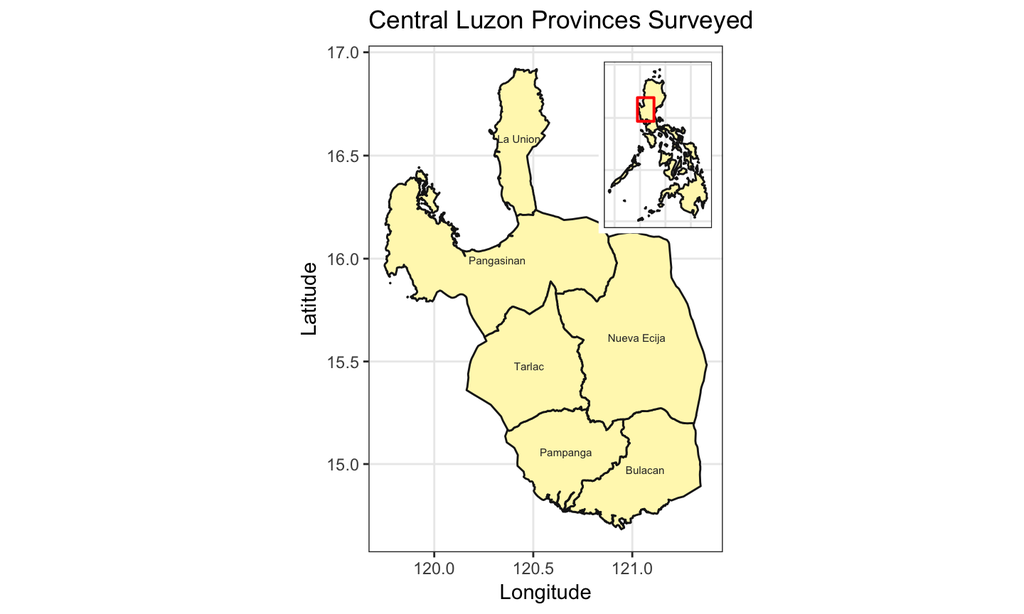

## Centroid Used to Query Stations

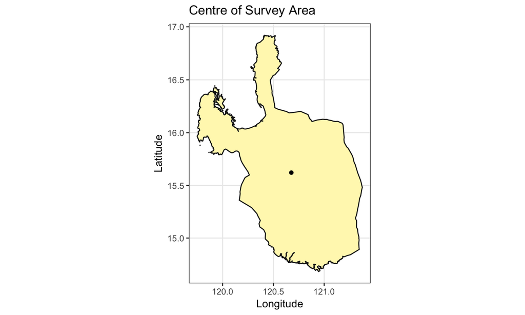